# HW 7 - KELLY “SCOTT” SIMS

Using the same crime data set uscrime.txt as in Questions 8.2 and 9.1, find the best model you can using (a) a regression tree model, and (b) a random forest model. In R, you can use the tree package or the rpart package, and the randomForest package. For each model, describe one or two qualitative takeaways you get from analyzing the results (i.e., don’t just stop when you have a good model, but interpret it too).

### Load Libraries

```r
library(rsample)     # data splitting
library(dplyr)       # data wrangling
library(rpart)       # performing regression trees
library(rpart.plot)  # plotting regression trees
library(randomForest)
library(h2o)
library(ggplot2)
library(caTools)
library(caret)
library(pROC)
```

### Load the data and inspect

```r
data <- read.table('uscrime.txt', header = TRUE, stringsAsFactors = FALSE)
#Separate independent and dependent variables just in case
Y = as.data.frame((data[,16]))
X = as.data.frame(data[,1:15])
head(data)
```

|  | M | So | Ed | Po1 | Po2 | LF | M.F | Pop | NW | U1 | U2 | Wealth | Ineq | Prob | Time | Crime |
| --- | --- | --- | --- | --- | --- | --- | --- | --- | --- | --- | --- | --- | --- | --- | --- | --- |
| 1 | 15.1 | 1 | 9.1 | 5.8 | 5.6 | 0.510 | 95.0 | 33 | 30.1 | 0.108 | 4.1 | 3940 | 26.1 | 0.084602 | 26.2011 | 791 |
| 2 | 14.3 | 0 | 11.3 | 10.3 | 9.5 | 0.583 | 101.2 | 13 | 10.2 | 0.096 | 3.6 | 5570 | 19.4 | 0.029599 | 25.2999 | 1635 |
| 3 | 14.2 | 1 | 8.9 | 4.5 | 4.4 | 0.533 | 96.9 | 18 | 21.9 | 0.094 | 3.3 | 3180 | 25.0 | 0.083401 | 24.3006 | 578 |
| 4 | 13.6 | 0 | 12.1 | 14.9 | 14.1 | 0.577 | 99.4 | 157 | 8.0 | 0.102 | 3.9 | 6730 | 16.7 | 0.015801 | 29.9012 | 1969 |
| 5 | 14.1 | 0 | 12.1 | 10.9 | 10.1 | 0.591 | 98.5 | 18 | 3.0 | 0.091 | 2.0 | 5780 | 17.4 | 0.041399 | 21.2998 | 1234 |
| 6 | 12.1 | 0 | 11.0 | 11.8 | 11.5 | 0.547 | 96.4 | 25 | 4.4 | 0.084 | 2.9 | 6890 | 12.6 | 0.034201 | 20.9995 | 682 |

## # CART

With regressions trees, there’s no need to scale the data before constructing a model. See quote below as noted from stats.stackexchange.com

> “Standardization does not add or subtract information contained in a given variable and does not distort its relationship to a target variable. For example, if you had a variable”age" which was a predictor for “purchase car”. By changing age to (age - mean / sd ) is not going to change its relationship to purchase car, it merely maps it to a new space. When CART looks for the best splits, it going to use entropy or gini to calculate information gain, this is not dependent on the scale of your predictor variable, rather on the resultant purity of the variable “purchase car”."

### Build the CART model

```r
cart_model <- rpart(
  formula = Crime ~ .,
  data    = data,
  method  = "anova"
  )
summary(cart_model)
```

```
Call:
rpart(formula = Crime ~ ., data = data, method = "anova")
  n= 47

          CP nsplit rel error    xerror      xstd
1 0.36296293      0 1.0000000 1.0305847 0.2597006
2 0.14814320      1 0.6370371 0.9549942 0.2291904
3 0.05173165      2 0.4888939 1.0562329 0.2361933
4 0.01000000      3 0.4371622 1.0693713 0.2362816

Variable importance
   Po1    Po2 Wealth   Ineq   Prob      M     NW    Pop   Time     Ed     LF     So
    17     17     11     11     10     10      9      5      4      4      1      1

Node number 1: 47 observations,    complexity param=0.3629629
  mean=905.0851, MSE=146402.7
  left son=2 (23 obs) right son=3 (24 obs)
  Primary splits:
      Po1    < 7.65      to the left,  improve=0.3629629, (0 missing)
      Po2    < 7.2       to the left,  improve=0.3629629, (0 missing)
      Prob   < 0.0418485 to the right, improve=0.3217700, (0 missing)
      NW     < 7.65      to the left,  improve=0.2356621, (0 missing)
      Wealth < 6240      to the left,  improve=0.2002403, (0 missing)
  Surrogate splits:
      Po2    < 7.2       to the left,  agree=1.000, adj=1.000, (0 split)
      Wealth < 5330      to the left,  agree=0.830, adj=0.652, (0 split)
      Prob   < 0.043598  to the right, agree=0.809, adj=0.609, (0 split)
      M      < 13.25     to the right, agree=0.745, adj=0.478, (0 split)
      Ineq   < 17.15     to the right, agree=0.745, adj=0.478, (0 split)

Node number 2: 23 observations,    complexity param=0.05173165
  mean=669.6087, MSE=33880.15
  left son=4 (12 obs) right son=5 (11 obs)
  Primary splits:
      Pop < 22.5      to the left,  improve=0.4568043, (0 missing)
      M   < 14.5      to the left,  improve=0.3931567, (0 missing)
      NW  < 5.4       to the left,  improve=0.3184074, (0 missing)
      Po1 < 5.75      to the left,  improve=0.2310098, (0 missing)
      U1  < 0.093     to the right, improve=0.2119062, (0 missing)
  Surrogate splits:
```

[output cut: 18 more lines]

```
      Time < 21.9001   to the left,  agree=0.750, adj=0.4, (0 split)
      Pop  < 30        to the left,  agree=0.708, adj=0.3, (0 split)
      LF   < 0.5885    to the right, agree=0.667, adj=0.2, (0 split)

Node number 4: 12 observations
  mean=550.5, MSE=20317.58

Node number 5: 11 observations
  mean=799.5455, MSE=16315.52

Node number 6: 10 observations
  mean=886.9, MSE=55757.49

Node number 7: 14 observations
  mean=1304.929, MSE=144801.8
```

The summary statistic above explains steps of the splits. For example, we start with n = 47 observations at the root node (very beginning) and the first variable we split on (the first variable that optimizes a reduction in SSE) is Po1. Node #2 has 23 observations and is split on Pop. Opposite of that node is Node #3 being split on NW. We could continue to analyze these superfluous statistics, but it is much easier to just visualize the tree itself.

## #Note:

### Plot the Regression Tree

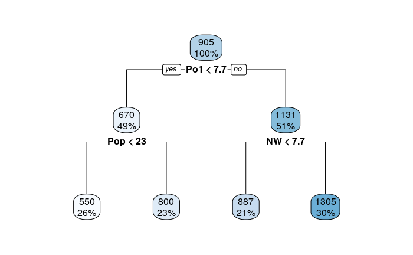

```r
rpart.plot(cart_model)
```

> Behind the scenes rpart is automatically applying a range of cost complexity (αlpha) values to prune the tree. To compare the error for each αlpha value, rpart performs a 10-fold cross validation so that the error associated with a given αlpha value is computed on the hold-out validation data.

In this example, we find diminishing returns for the 4 terminal nodes as seen blelow. The y-axis is the cross validation error. The lower x-axis is cost complexity parameter (alpha), and the upper x-axis is the number of terminal nodes. The complexity parameter (cp) is used to control the size of the decision tree and to select the optimal tree size. If the cost of adding another variable to the decision tree from the current node is above the value of cp, then tree building does not continue. We could also say that tree construction does not continue unless it would decrease the overall lack of fit by a factor of cp.

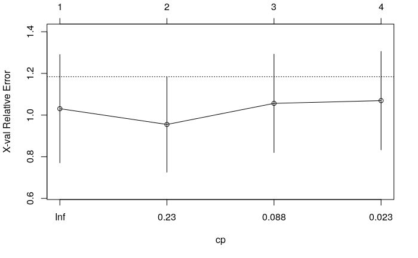

```r
plotcp(cart_model)
```

### Tuning the model with Gridsearch

In addition to the cost complexity parameter, it is also common to tune:

1. minsplit: the minimum number of data points required to attempt a split before it is forced to create a terminal node. The default is 20. Making this smaller allows for terminal nodes that may contain only a handful of observations to create the predicted value.
2. maxdepth: the maximum number of internal nodes between the root node and the terminal nodes. The default is 30, which is quite liberal and allows for fairly large trees to be built.

To perform a grid search we first create our hyperparameter grid. In this example, I search a range of minsplit from 1-20 and vary maxdepth from 2-15. This gives 280 different hyperparameter combinations to try.

```r
hyper_grid <- expand.grid(
  minsplit = seq(1, 20, 1),
  maxdepth = seq(2, 15, 1)
)
head(hyper_grid)
```

|  | minsplit | maxdepth |
| --- | --- | --- |
| 1 | 1 | 2 |
| 2 | 2 | 2 |
| 3 | 3 | 2 |
| 4 | 4 | 2 |
| 5 | 5 | 2 |
| 6 | 6 | 2 |

```r
length(hyper_grid[,1])
```

```
[1] 280
```

# Iterate through the hypergrid creating a model for each combination

We will store the resulting model in a list called models. We will use this list of models to extract the best one

```r
models <- list()
for (i in 1:nrow(hyper_grid)) {

  # get minsplit, maxdepth values at row i
  minsplit <- hyper_grid$minsplit[i]
  maxdepth <- hyper_grid$maxdepth[i]
  # train a model and store in the list
  models[[i]] <- rpart(
    formula = Crime ~ .,
    data    = data,
    method  = "anova",
    control = list(minsplit = minsplit, maxdepth = maxdepth)
    )
}
```

# Extract the best performing models, and their subsequent hyperparameters

Next, from each model, we will extract the lowest **xerror** and the lowest **cp** value for each model, and append those values to the hypergrid next to their subseqent hyperparameters. We will then sort the hypergrid by lowest error and pick the best performing model.

```r
# function to get optimal cp
get_cp <- function(x) {
  min    <- which.min(x$cptable[, "xerror"])
  cp <- x$cptable[min, "CP"]
}
# function to get minimum error
get_min_error <- function(x) {
  min    <- which.min(x$cptable[, "xerror"])
  xerror <- x$cptable[min, "xerror"]
}
hyper_grid %>%
  mutate(
    cp    = purrr::map_dbl(models, get_cp),
    error = purrr::map_dbl(models, get_min_error)
    ) %>%
  arrange(error) %>%
  top_n(-5, wt = error)
```

| minsplit | maxdepth | cp | error |
| --- | --- | --- | --- |
| 17 | 6 | 0.01 | 0.6916775 |
| 4 | 11 | 0.01 | 0.7063107 |
| 7 | 14 | 0.01 | 0.7092623 |
| 10 | 11 | 0.01 | 0.7202334 |
| 3 | 7 | 0.01 | 0.7296096 |

# Best Model

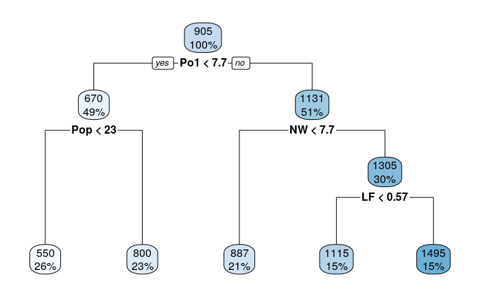

```r
optimal_tree <- rpart(
    formula = Crime ~ .,
    data    = data,
    method  = "anova",
    control = list(minsplit = 8, maxdepth = 9, cp = 0.01)
    )
rpart.plot(optimal_tree)
```

### Prediction

```r
new.data <- data.frame("M"= 14,
"So" = 0,
"Ed" = 10,
"Po1" = 12,
"Po2" = 15.5,
"LF" = .640,
"M.F" = 94,
"Pop" = 150,
"NW" = 1.1,
"U1" = .120,
"U2" = 3.6,
"Wealth" = 3200,
"Ineq" = 20.1,
"Prob" = .04,
"Time" = 39)
predict(optimal_tree, newdata = new.data)
```

```
    1
886.9
```

***Analysis** We can see that the predicted crime average is 887. This seems lower than what other models had been predicting in weeks past. If you trace the regression tree, we can see exactly where the model divered from expectations. Po1 for the new data is greater than 7.7, so we go to the right side of the tree. Next, we can see that NW is less than the constraint 7.7, so this moves of to the left of that node, bringing us to 887. Had it not been for that one lower value, we can see on the right side of that split, our data is larger than 0.57 for LF, and that would have brought us around the crime average we have been seeing, 1495.

## # RANDOM FOREST

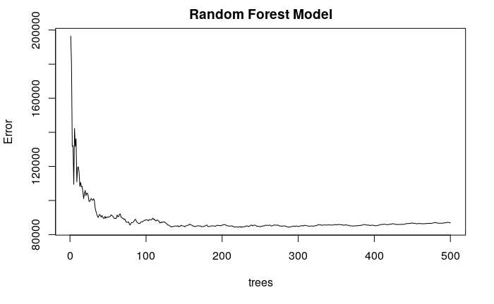

```r
set.seed(42)
RF_model <- randomForest(
  formula = Crime ~ .,
  data    = data
)
plot(RF_model, main = 'Random Forest Model')
```

```r
# number of trees with lowest MSE
which.min(RF_model$mse)
```

```
[1] 225
```

```r
# RMSE of this optimal random forest
sqrt(RF_model$mse[which.min(RF_model$mse)])
```

```
[1] 290.168
```

In the plot above we can see the model that produces the lowest (best) error has about 225 Trees. It’s RMSE is 290. After that, the graph flattens out without much of any improvement. randomForest allows the use of crossvalidation in order to train a model as well

### Note - the following example is one adapted from an online source. It is not my original code

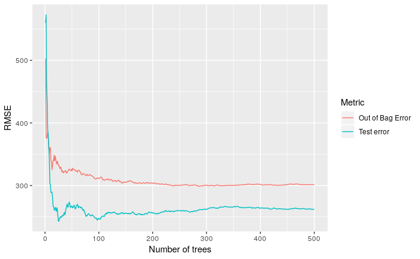

```r
set.seed(24)
valid_split <- initial_split(data, .8)
# training data
train <- analysis(valid_split)
# validation data
valid <- assessment(valid_split)
x_test <- valid[setdiff(names(valid), "Crime")]
y_test <- valid$Crime
rf_oob_comp <- randomForest(
  formula = Crime ~ .,
  data    = train,
  xtest   = x_test,
  ytest   = y_test
)
# extract OOB & validation errors
oob <- sqrt(rf_oob_comp$mse)
validation <- sqrt(rf_oob_comp$test$mse)
# compare error rates
tibble::tibble(
  `Out of Bag Error` = oob,
  `Test error` = validation,
  ntrees = 1:rf_oob_comp$ntree
) %>%
  gather(Metric, RMSE, -ntrees) %>%
  ggplot(aes(ntrees, RMSE, color = Metric)) +
  geom_line() +
  scale_y_continuous() +
  xlab("Number of trees")
```

### Tuning

The following is quote from source - https://uc-r.github.io/random_forests

> Random forests are fairly easy to tune since there are only a handful of tuning parameters. Typically, the primary concern when starting out is tuning the number of candidate variables to select from at each split. However, there are a few additional hyperparameters that we should be aware of. Although the argument names may differ across packages, these hyperparameters should be present: * ntree: number of trees. We want enough trees to stabalize the error but using too many trees is unncessarily inefficient, especially when using large data sets. * mtry: the number of variables to randomly sample as candidates at each split. When mtry =p the model equates to bagging. When mtry = 1 the split variable is completely random, so all variables get a chance but can lead to overly biased results. A common suggestion is to start with 5 values evenly spaced across the range from 2 to p. * sampsize: the number of samples to train on. The default value is 63.25% of the training set since this is the expected value of unique observations in the bootstrap sample. Lower sample sizes can reduce the training time but may introduce more bias than necessary. Increasing the sample size can increase performance but at the risk of overfitting because it introduces more variance. Typically, when tuning this parameter we stay near the 60-80% range. * nodesize: minimum number of samples within the terminal nodes. Controls the complexity of the trees. Smaller node size allows for deeper, more complex trees and smaller node results in shallower trees. This is another bias-variance tradeoff where deeper trees introduce more variance (risk of overfitting) and shallower trees introduce more bias (risk of not fully capturing unique patters and relatonships in the data). * maxnodes: maximum number of terminal nodes. Another way to control the complexity of the trees. More nodes equates to deeper, more complex trees and less nodes result in shallower trees.